# Non-contiguous hexograms

Local Authority and Middle-layer Super Output Area exmaples

Tom Rushby

25/06/2021

# 1 Setup

```r
knitr::opts_chunk$set(echo = TRUE)
knitr::opts_chunk$set(out.width = "100%")
```

```r
library(curl)
library(sf)
library(tidyverse)
```

```r
library(ggplot2)
```

# 2 Introduction

One of the problems associated with mapping area-based data is the often highly variable size of geographical areas. With data such as that provided by Census (OA, LSOA, MSOA etc) representing similar populations, the dominance of the largest areas can lead to mis-interpretation (and potential overlooking of smaller areas). Cartograms have been used to resize areas in accordance with other attributes such as population. For more background and creating hexograms in R see [Hexograms: better maps of area based data](https://rstudio-pubs-static.s3.amazonaws.com/342278_51068843182b41ad9e00dfcc35e65247.html).

# 3 Examples

This example follows an example of creating a non-contiguous hexogram (and re-uses code) by [@VictimOfMaths](https://github.com/VictimOfMaths/Maps/blob/master/WFHCartogram.R) using hex-map geometry from [House of Commons Library](https://github.com/houseofcommonslibrary/uk-hex-cartograms-noncontiguous/).

The first example we will look at is plotting a non-contiguous hexogram of Local Authority areas.

## 3.1 Local Authority areas

```r
ltla <- tempfile()
source <- ("https://github.com/houseofcommonslibrary/uk-hex-cartograms-noncontiguous/raw/main/geopackages/LocalAuthorities-lowertier.gpkg")
ltla <- curl_download(url=source, destfile=ltla, quiet=FALSE, mode="wb")
```

The file downloaded is a GeoPackage (.gpkg) file, an SQLite Database container (see http://www.geopackage.org/guidance/getting-started.html for more info.). We can examine the layers contained using the `st_layers()` command from the sf package.

```r
st_layers(ltla)
```

```
## Driver: GPKG
## Available layers:
##       layer_name geometry_type features fields
## 1 1 Group labels         Point       60      4
## 2       2 Groups Multi Polygon       61      5
## 3    3 LTLA-2018 Multi Polygon      391      8
## 4    4 LTLA-2019 Multi Polygon      382      8
## 5    5 LTLA-2020 Multi Polygon      379      8
## 6    6 LTLA-2021 Multi Polygon      374      8
## 7   7 Background Multi Polygon        3      2
## 8   layer_styles            NA        7     12
```

Next we extract the layers we want using the `st_read` command. [Alternative methods](https://olalladiaz.net/blog/2018/11/02/working-with-gpkg-r/) are available.

```r
Background <- st_read(ltla, layer="7 Background")
Areas <- st_read(ltla, layer="4 LTLA-2019")
Groups <- st_read(ltla, layer="2 Groups")
Group_labels <- st_read(ltla, layer="1 Group labels") %>%
  mutate(just=if_else(LabelPosit=="Left", 0, 1))
```

And finally we can make a plot, for example Figure 3.1 note the `Groups` geometry provides County-level grouping of local authorities and an outline (appears bold in the plot below). `Areas` provides the local authority outlines.

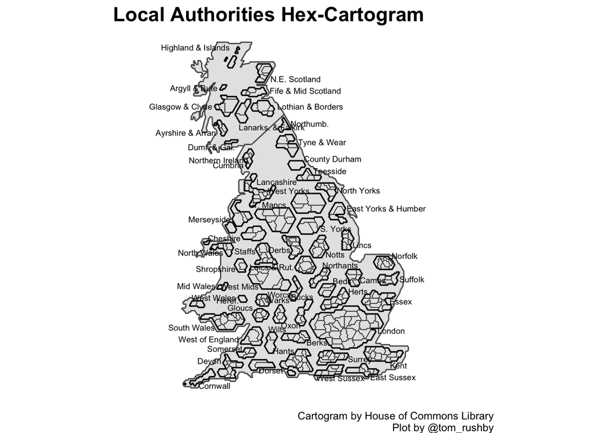

Figure 3.1: Non-contiguous hexogram of local authorities in Great Britain

# 4 Middle-layer Super Output Areas

Load GeoPackage file … this time Middle-layer Super Output Areas (MSOAs) in England and Wales only.

```r
msoa <- tempfile()
source <- ("https://github.com/houseofcommonslibrary/uk-hex-cartograms-noncontiguous/raw/main/geopackages/MSOA.gpkg")
msoa <- curl_download(url = source, destfile = msoa, quiet = FALSE, mode = "wb")
```

List layers …

```r
st_layers(msoa)
```

```
## Driver: GPKG
## Available layers:
##                          layer_name geometry_type features fields
## 1                    1 Group labels         Point       50      4
## 2                          2 Groups Multi Polygon       51      3
## 3 3 Local authority outlines (2019) Multi Polygon      339      8
## 4                        4 MSOA hex Multi Polygon     7201     13
## 5                      5 Background Multi Polygon        1      2
## 6                      layer_styles            NA        5     12
```

Extract layers …

```r
background_msoa <- st_read(msoa, layer="5 Background")
msoa_la_outlines <- st_read(msoa, layer="3 Local authority outlines (2019)")
msoa_data <- st_read(msoa, layer="4 MSOA hex")
msoa_groups <- st_read(msoa, layer="2 Groups")
msoa_group_labels <- st_read(msoa, layer="1 Group labels") %>%
  mutate(just=if_else(LabelPosit=="Left", 0, 1))
```

Figure 4.1 As with the local authority example, `msoa_groups` and `msoa_la_outlines` geometries provide County- and Local Authority-level grouping/outlines (black in the plot below). `msoa_data` provides the MSOA outlines (in blue).

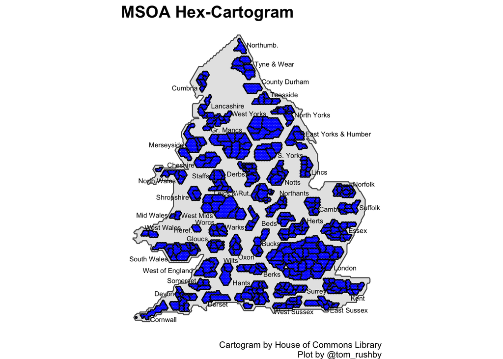

# 5 Further reading and resources

I cannot find LSOA level hex maps but here’s some links with a more info on creating hex maps, something to try out!

- Sam Langton: [Data visualisation in R: extras](https://rpubs.com/langton_/worksheet-extras-03)
- Simon Hailstone: [Playing with the hexmapr and fingertipsR packages](https://rpubs.com/Hailstone/326118)
- Richard Harris: [Hexograms: better maps of area based data](https://rstudio-pubs-static.s3.amazonaws.com/342278_51068843182b41ad9e00dfcc35e65247.html)

Other resources …

- https://docs.evanodell.com/parlitools/ and https://docs.evanodell.com/parlitools/articles/using-cartograms.html

ODI Leeds …

- https://odileeds.github.io/covid-19/LocalAuthorities/hexmap.html
- https://github.com/odileeds/hexmaps